# My Commute Patterns: A Visual Data Story

## Commute Frequency by Day Type

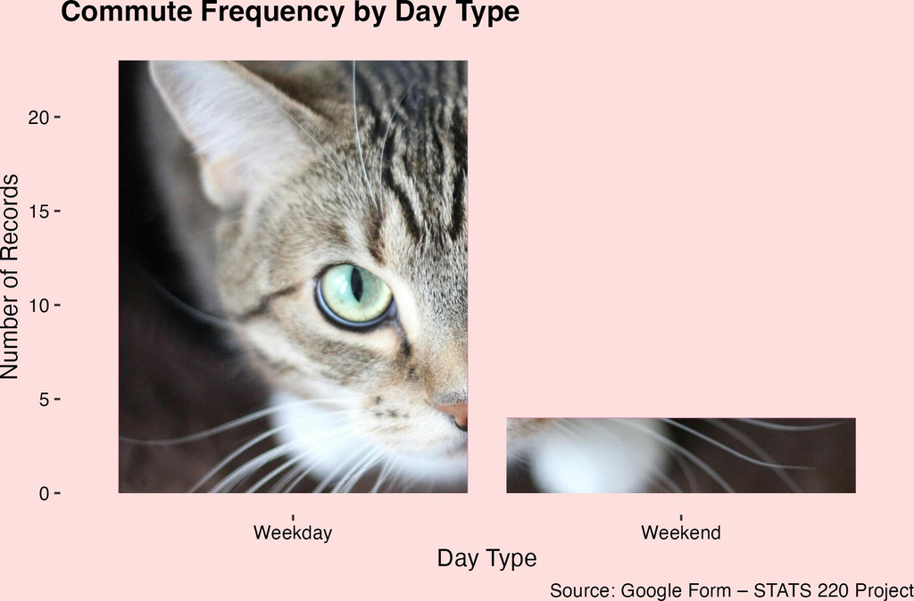

Bar chart showing weekday commutes are more frequent than weekends

This bar chart shows that I commute more frequently on weekdays than weekends.

## Transport Modes by Day Type

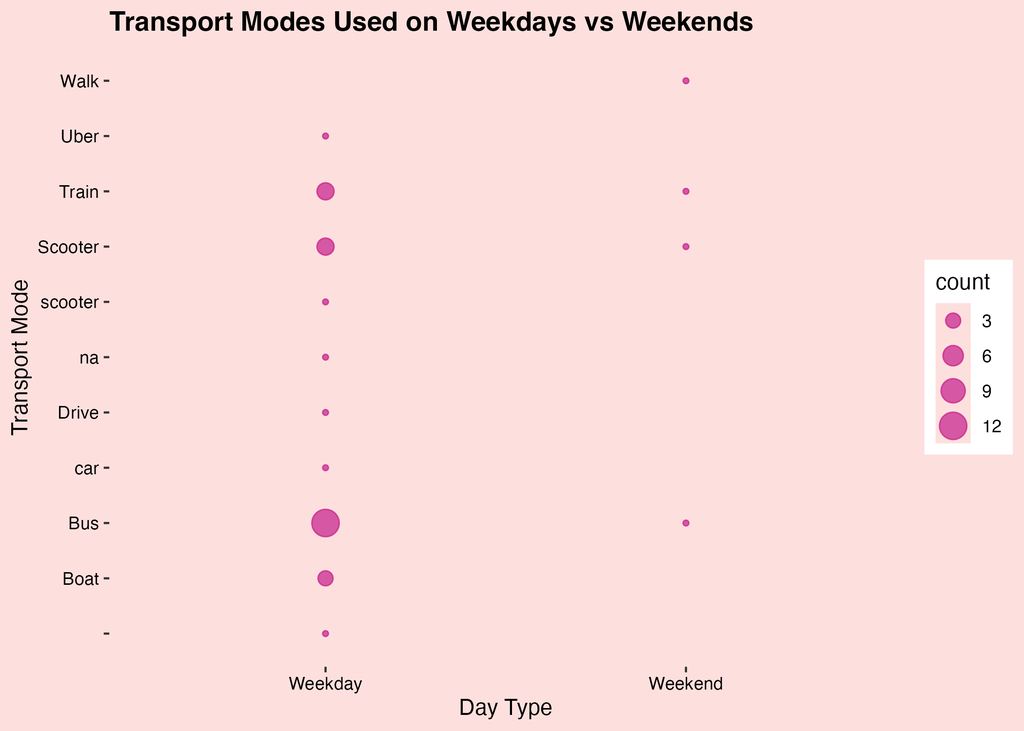

Dot plot showing buses and trains are used more on weekdays, while walking is more frequent on weekends

This dot plot shows which transport modes I use on weekdays vs weekends.

## When Do I Usually Commute?

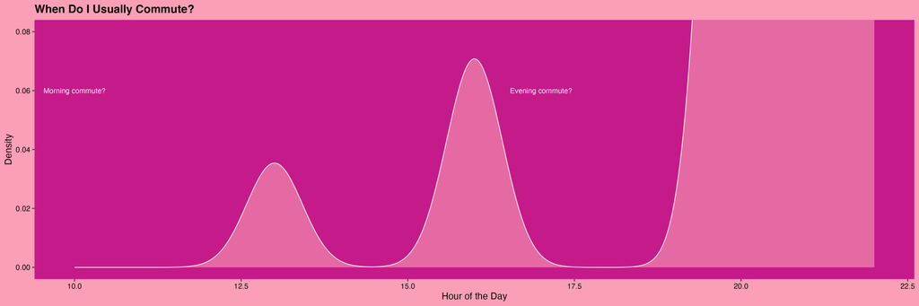

## Exploring My Commute: When, How, and How Often I Travel

I collected data about my commuting habits using a Google Form, where I recorded whether the day was a weekday or a weekend, which modes of public transport I used, and the time I logged my commute. The goal was to explore how my commute patterns change depending on the type of day and time.

The *first plot* shows a clear difference in frequency: I commute far more on weekdays than weekends, which aligns with my usual work schedule. To make the plot visually engaging, I used the **cuttingshapes** package to integrate a cat image into the bar chart — a fun way to present familiar data.

In the *second plot* , I broke down my transport modes using a bubble chart. Buses and trains appear more frequently on weekdays, while walking is more common on weekends. This suggests I stay local on weekends and rely on public transport mainly for weekday responsibilities.

Through this project, I was able to turn everyday data into meaningful insights about my own behavior. The process also gave me a chance to combine visual storytelling with creativity and data skills — and of course, some cats.